# **Feature Engineering, Selection, and Scaling**

## Objectives

**Perform Business requirement 2 user story task: Feature engineering, selection, and scaling ML tasks**

- Perform categorical encoding for categorical features.
- Perform feature selection to distill the most significant features, and also remove redundant features.
- Carry out feature scaling/transformations to normalise/standardise the distributions of remaining features.
- Determine some of the steps to be included in the data cleaning and feature engineering pipeline.
- cleaned train set: outputs/datasets/ml/cleaned/train_set.csv
- cleaned test set: outputs/datasets/ml/cleaned/test_set.csv

## Outputs

- Specified data cleaning and engineering pipeline steps to include.
- CompositeSelectKBest custom transformer for use as a feature selection step in the pipelines.

## Change working directory

Working directory changed to its parent folder.

```python
import os
current_dir = os.getcwd()
current_dir
```

```
'/workspace/heritage_housing_issues/jupyter_notebooks'
```

```python
os.chdir(os.path.dirname(current_dir))
os.getcwd()
```

```
'/workspace/heritage_housing_issues'
```

## Load cleaned train and test datasets

```python
import pandas as pd

train_set_df = pd.read_csv(filepath_or_buffer='outputs/datasets/ml/cleaned/train_set.csv')
test_set_df = pd.read_csv(filepath_or_buffer='outputs/datasets/ml/cleaned/test_set.csv')
```

## Categorical feature encoding

In the sale price correlation study notebook, the categorical features were encoded using an ordinal encoder; this was deemed most suitable since all the cateogrical features are ordinal, with an obvious ordering based around a rating.

The exact same encoding will be used for the cleaned train and test sets.

```python
train_set_categorical_df = train_set_df.select_dtypes(include='object')
print(train_set_categorical_df.columns)
test_set_categorical_df = test_set_df.select_dtypes(include='object')
test_set_categorical_df.columns
```

```
Index(['BsmtExposure', 'BsmtFinType1', 'GarageFinish', 'KitchenQual'], dtype='object')
```

```
Index(['BsmtExposure', 'BsmtFinType1', 'GarageFinish', 'KitchenQual'], dtype='object')
```

```python
from sklearn.preprocessing import OrdinalEncoder
import numpy as np

# Designating the ordered categories
bsmt_fin_type1_cat = np.array(list(reversed(['GLQ', 'ALQ', 'BLQ', 'Rec', 'LwQ', 'Unf', 'None'])))
bsmt_exposure_cat = np.array(['None', 'No', 'Mn', 'Av', 'Gd'])
garage_finish_cat = np.array(['None', 'Unf', 'RFn', 'Fin'])
kitchen_quality_cat = np.array(['Po', 'Fa', 'TA', 'Gd', 'Ex'])

categories = [bsmt_exposure_cat, bsmt_fin_type1_cat, garage_finish_cat, kitchen_quality_cat]
encoder = OrdinalEncoder(categories=categories, dtype='int64')
encoder.set_output(transform='pandas')

# fitting and transforming each set
train_set_categorical_df = encoder.fit_transform(X=train_set_categorical_df)
train_set_df[train_set_categorical_df.columns] = train_set_categorical_df
print(train_set_df[train_set_categorical_df.columns].head())
test_set_categorical_df = encoder.transform(X=test_set_categorical_df)
test_set_df[test_set_categorical_df.columns] = test_set_categorical_df
test_set_df[test_set_categorical_df.columns].head()
```

```
   BsmtExposure  BsmtFinType1  GarageFinish  KitchenQual
0             1             5             1            3
1             3             5             3            3
2             4             6             3            3
3             1             6             2            3
4             1             6             1            3
```

|  | BsmtExposure | BsmtFinType1 | GarageFinish | KitchenQual |
| --- | --- | --- | --- | --- |
| 0 | 1 | 5 | 1 | 2 |
| 1 | 3 | 6 | 2 | 3 |
| 2 | 4 | 6 | 1 | 3 |
| 3 | 1 | 1 | 2 | 3 |
| 4 | 2 | 1 | 2 | 3 |

## Initial feature selection

It was decided to perform an initial feature selection before feature scaling, for primarily two reasons. Firstly there is quite a large number of features (23), for which performing feature scaling would be time consuming, as well as pointless for several features which have much less significance with regard to the target; this was already discovered in the sales price correlation study notebook, where a group of significant features was generated using correlation tests and PPS's applied to the whole dataset. The second reason is that as this initial selection will not use a ML model to establish the significant features, scaling is not important.

Instead a similar approach to that used in the sales price correlation study involving correlation tests, but with the 'selectKBest method', will be used --- again this is not affected by scaling.

After this is performed, feature-feature correlations will be assessed, and one of the features of any strongly correlated group will be dropped in order to reduce redundancy; which was seen to exist in the significant feature EDA notebook. A decision tree algorithm will be used, as this is unaffected by scaling.

Feature scaling will then be performed on the most significant features, before a further feature selection will occur that relies on scale affected ML models. Since scaling has been performed, this should pose no issues.

**SelectKBest feature selection**

The SelectKBest feature selection will be performed twice, once using the Spearman correlation test, then using the phi_k correlation test.

Creating the score functions

```python
import pingouin as pg
from sklearn.feature_selection import SelectKBest

def spearman_score_function(feature_array, target_array):
    """
    Calculates spearman correlation coefficients for the train or test set.

    To be used as the score function in the sklearn.feature_selection.SelectKBest function.

    Args:
        feature_array = array-like, containing train or test set feature data.
        target_array = array-like, containing train or test set target data

    Returns tuple of the spearman r values series, and the spearman p values series for the dataset.
    """
    column_names = train_set_df.columns.to_list()
    df = pd.DataFrame(data=feature_array, columns=column_names[0:-1])
    df['SalePrice'] = target_array
    spearman_df = df.pairwise_corr(columns=['SalePrice'], method='spearman')
    print('Spearman coefficients')
    print(spearman_df.sort_values(by='r')[['X', 'Y', 'r', 'p-unc']])
    return (spearman_df['r'], spearman_df['p-unc'])
```

```python
import phik
from phik.phik import phik_matrix
from phik.report import plot_correlation_matrix
from phik.significance import significance_matrix

def phik_score_function(feature_array, target_array,):
    """
    Calculates phi_k correlation coefficients for the train or test set.

    To be used as the score function in the sklearn.feature_selection.SelectKBest function.

    Args:
        feature_array = array-like, containing train or test set feature data.
        target_array = array-like, containing train or test set target data

    Returns tuple of the phi_k correlation values series, and the significance values series for the dataset.
    """
    column_names = train_set_df.columns.to_list()
    df = pd.DataFrame(data=feature_array, columns=column_names[0:-1])
    df['SalePrice'] = target_array

    phik_matrix_df = phik_matrix(df)[['SalePrice']].drop('SalePrice', axis=0)
    significance_matrix_df = significance_matrix(df)[['SalePrice']].drop('SalePrice', axis=0)
    print('phi_k coefficients')
    print(phik_matrix_df)

    return (phik_matrix_df['SalePrice'], significance_matrix_df['SalePrice'])
```

Will take the union of filtered out features using each score function.

```python
def filter_out_best_features(df):
    """
    Applies a SelectKBest transformer, once with a spearman score function, and then with a phi_k score function.

    Args:
        df: train or test set dataframe containing features and a target.

    Returns a list of the union of the k-best-selected features generated using each score function.
    """
    select_k_best = SelectKBest(score_func=spearman_score_function)
    select_k_best.set_output(transform='pandas')
    train_set_spearman_transformed_df = select_k_best.fit_transform(df.drop('SalePrice', axis=1), df['SalePrice'])

    select_k_best = SelectKBest(score_func=phik_score_function)
    select_k_best.set_output(transform='pandas')
    train_set_phik_transformed_df = select_k_best.fit_transform(df.drop('SalePrice', axis=1), df['SalePrice'])

    return list(set(train_set_spearman_transformed_df.columns.to_list() + train_set_phik_transformed_df.columns.to_list()))
```

```python
selected_features = filter_out_best_features(train_set_df)
```

```
Spearman coefficients
            X                Y         r          p-unc
7   SalePrice  EnclosedPorchSF -0.201333   1.888443e-11
17  SalePrice      OverallCond -0.146518   1.159225e-06
20  SalePrice       WoodDeckSF  0.079040   8.974717e-03
6   SalePrice        BsmtUnfSF  0.189735   2.612622e-10
2   SalePrice     BedroomAbvGr  0.224664   5.830101e-14
1   SalePrice         2ndFlrSF  0.267766   2.191974e-19
4   SalePrice       BsmtFinSF1  0.305735   4.637648e-25
3   SalePrice     BsmtExposure  0.335329   4.176997e-30
5   SalePrice     BsmtFinType1  0.347822   2.080694e-32
14  SalePrice      LotFrontage  0.393230   1.063675e-41
15  SalePrice       MasVnrArea  0.424247   6.114442e-49
13  SalePrice          LotArea  0.430794   1.440301e-50
16  SalePrice      OpenPorchSF  0.491026   2.450532e-67
22  SalePrice     YearRemodAdd  0.550675   1.320443e-87
9   SalePrice     GarageFinish  0.557334   3.942119e-90
0   SalePrice         1stFlrSF  0.566254   1.326225e-93
19  SalePrice      TotalBsmtSF  0.594764  1.898096e-105
10  SalePrice      GarageYrBlt  0.595514  8.930134e-106
8   SalePrice       GarageArea  0.634539  4.253739e-124
21  SalePrice        YearBuilt  0.640190  5.669282e-127
12  SalePrice      KitchenQual  0.685548  1.940258e-152
11  SalePrice        GrLivArea  0.726061  1.732350e-179
18  SalePrice      OverallQual  0.814342  8.365626e-260
interval columns not set, guessing: ['1stFlrSF', '2ndFlrSF', 'BedroomAbvGr', 'BsmtExposure', 'BsmtFinSF1', 'BsmtFinType1', 'BsmtUnfSF', 'EnclosedPorchSF', 'GarageArea', 'GarageFinish', 'GarageYrBlt', 'GrLivArea', 'KitchenQual', 'LotArea', 'LotFrontage', 'MasVnrArea', 'OpenPorchSF', 'OverallCond', 'O…
interval columns not set, guessing: ['1stFlrSF', '2ndFlrSF', 'BedroomAbvGr', 'BsmtExposure', 'BsmtFinSF1', 'BsmtFinType1', 'BsmtUnfSF', 'EnclosedPorchSF', 'GarageArea', 'GarageFinish', 'GarageYrBlt', 'GrLivArea', 'KitchenQual', 'LotArea', 'LotFrontage', 'MasVnrArea', 'OpenPorchSF', 'OverallCond', 'O…
phi_k coefficients
                 SalePrice
1stFlrSF          0.719800
2ndFlrSF          0.655025
BedroomAbvGr      0.265028
BsmtExposure      0.479725
BsmtFinSF1        0.755908
BsmtFinType1      0.355595
BsmtUnfSF         0.450158
EnclosedPorchSF   0.246695
GarageArea        0.722796
GarageFinish      0.542912
GarageYrBlt       0.532663
GrLivArea         0.780347
KitchenQual       0.688180
LotArea           0.297655
LotFrontage       0.293609
MasVnrArea        0.629938
OpenPorchSF       0.302085
OverallCond       0.364668
OverallQual       0.838698
TotalBsmtSF       0.800877
WoodDeckSF        0.220363
YearBuilt         0.605525
YearRemodAdd      0.453246
```

**Best features list**

```python
print('Number of features:', len(selected_features))
selected_features
```

```
Number of features: 13
```

```
['MasVnrArea',
 'GarageArea',
 'TotalBsmtSF',
 'YearBuilt',
 'BsmtFinSF1',
 'GarageYrBlt',
 'GrLivArea',
 'OverallQual',
 'GarageFinish',
 'YearRemodAdd',
 'KitchenQual',
 '1stFlrSF',
 '2ndFlrSF']
```

Can see that most of the selected features match those selected during the sale price correlation study notebook using the whole dataset.

Now will manually transform the train set by filtering out only the selected features. Will also filter out the same features from the test set, in order to avoid data leakage by selecting the best features separately using the test set instead.

```python
train_set_df = train_set_df[selected_features + ['SalePrice']]
test_set_df = test_set_df[selected_features + ['SalePrice']]
```

### Handling redundant features

Will select a single feature from any highly correlated feature groups, using the Spearman correlation test.

```python
from feature_engine.selection import SmartCorrelatedSelection
from sklearn.tree import DecisionTreeRegressor

estimator = DecisionTreeRegressor(min_samples_split=10, min_samples_leaf=5, random_state=30)
smart_correlated_transformer = SmartCorrelatedSelection(train_set_df.drop('SalePrice', axis=1).columns.to_list(),
                                                        method='spearman', threshold=0.8, selection_method='model_performance',
                                                        estimator=estimator, scoring='r2', cv=5)
```

fitting to train set

```python
smart_correlated_transformer.fit(X=train_set_df, y=train_set_df['SalePrice'])
```

```
SmartCorrelatedSelection(cv=5,
                         estimator=DecisionTreeRegressor(min_samples_leaf=5,
                                                         min_samples_split=10,
                                                         random_state=30),
                         method='spearman', scoring='r2',
                         selection_method='model_performance',
                         variables=['MasVnrArea', 'GarageArea', 'TotalBsmtSF',
                                    'YearBuilt', 'BsmtFinSF1', 'GarageYrBlt',
                                    'GrLivArea', 'OverallQual', 'GarageFinish',
                                    'YearRemodAdd', 'KitchenQual', '1stFlrSF',
                                    '2ndFlrSF'])
```

```python
for statement in [smart_correlated_transformer.variables,
                  smart_correlated_transformer.correlated_feature_sets_,
                  smart_correlated_transformer.features_to_drop_]:
                  print(statement)
```

```
['MasVnrArea', 'GarageArea', 'TotalBsmtSF', 'YearBuilt', 'BsmtFinSF1', 'GarageYrBlt', 'GrLivArea', 'OverallQual', 'GarageFinish', 'YearRemodAdd', 'KitchenQual', '1stFlrSF', '2ndFlrSF']
[{'TotalBsmtSF', '1stFlrSF'}, {'YearBuilt', 'GarageYrBlt'}]
['GarageYrBlt', '1stFlrSF']
```

transforming train set

```python
train_set_df = smart_correlated_transformer.transform(train_set_df)
```

transforming test set

```python
test_set_df = smart_correlated_transformer.transform(test_set_df)
```

## Feature scaling

Will aim to attempt to standardise the distributions of the numeric features of the train and test sets. Will try variance-stabilizing-transformers, the standardiser method, or the normalisation method to achieve this, and evaluate the results.

```python
train_set_df.columns.to_list()
```

```
['MasVnrArea',
 'GarageArea',
 'TotalBsmtSF',
 'YearBuilt',
 'BsmtFinSF1',
 'GrLivArea',
 'OverallQual',
 'GarageFinish',
 'YearRemodAdd',
 'KitchenQual',
 '2ndFlrSF',
 'SalePrice']
```

```python
train_set_numeric_df = train_set_df.drop(['OverallQual', 'KitchenQual', 'GarageFinish', 'SalePrice'], axis=1)
test_set_numeric_df  = test_set_df.drop(['OverallQual', 'KitchenQual', 'GarageFinish', 'SalePrice'], axis=1)
```

Creating functions to carry out transformations, and evaluate the transformer effect, for each numeric feature.

```python
import matplotlib.pyplot as plt
import seaborn as sns

def evaluate_scaling_transformation(feature_data, transformed_distribution, fig_title=None):
    """
    Plots histograms, box plots, QQ plots to compare feature distributions before and after a transformation.

    Args:
        feature_data: dataframe containing untransformed numeric features.
        transformed_distribution: dataframe containing transformed numeric features.
        fig_title (str): Global figure title for a set of subplots.
    """
    fig, axes = plt.subplots(ncols=2, nrows=3, figsize=(10,9), tight_layout=True)
    fig.suptitle(fig_title)

    plot = sns.histplot(data=feature_data, x=feature_data.iloc[:,0], ax=axes[0][0])
    plot.set(title='Before')
    plot = sns.histplot(data=transformed_distribution, x=transformed_distribution.iloc[:,0], ax=axes[0][1])
    plot.set(title='After')

    plot = sns.boxplot(data=feature_data, x=feature_data.iloc[:,0], ax=axes[1][0], orient='h')
    plot.set(title='Before')
    plot = sns.boxplot(data=transformed_distribution, x=transformed_distribution.iloc[:,0], ax=axes[1][1], orient='h')
    plot.set(title='After')

    plot = pg.qqplot(x=feature_data.iloc[:,0], ax=axes[2][0])
    plot.set(title='Before')
    plot = pg.qqplot(x=transformed_distribution.iloc[:,0], ax=axes[2][1])
    plot.set(title='After')
```

```python
def evaluate_all_feature_transformations(transformer, non_zero=False):
    """
    Applies transformer to all numeric features of the train set. Produces plot for before and after comparisons.

    Args:
        transformer: transformer object.
        non-zero (bool): indicates whether only features with non-zero values should be used.
    """
    if not non_zero:
        df = transformer.fit_transform(train_set_numeric_df)
    else:
        df = transformer.fit_transform(train_set_numeric_df.loc[:,(train_set_numeric_df > 0).all().values.tolist()])

    for feature in df.items():
        evaluate_scaling_transformation(train_set_numeric_df[[feature[0]]], df[[feature[0]]], feature[0])
```

MinMaxScaler transformer:

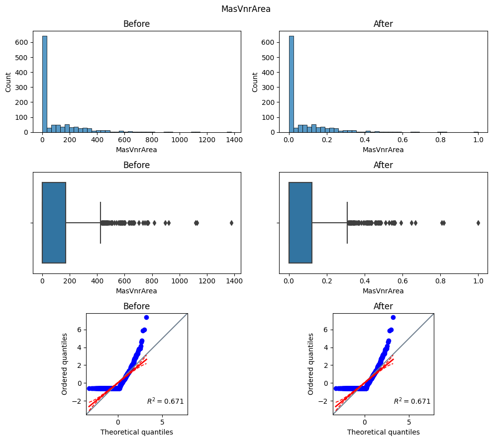

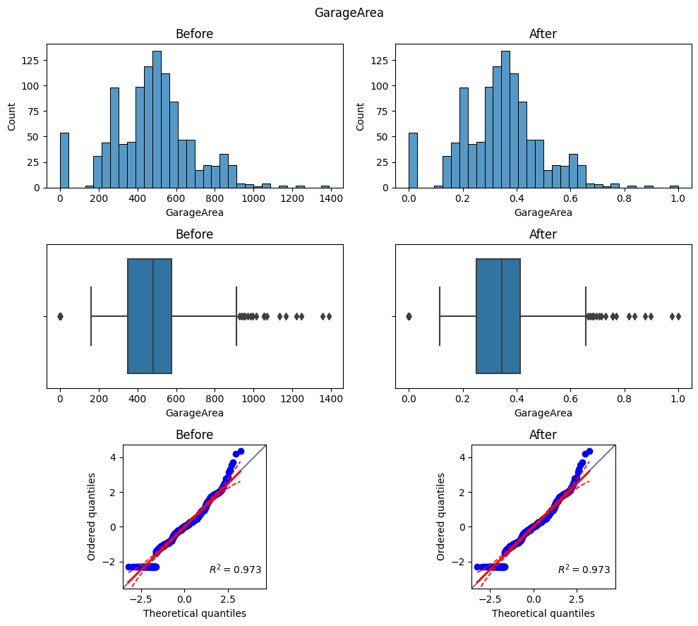

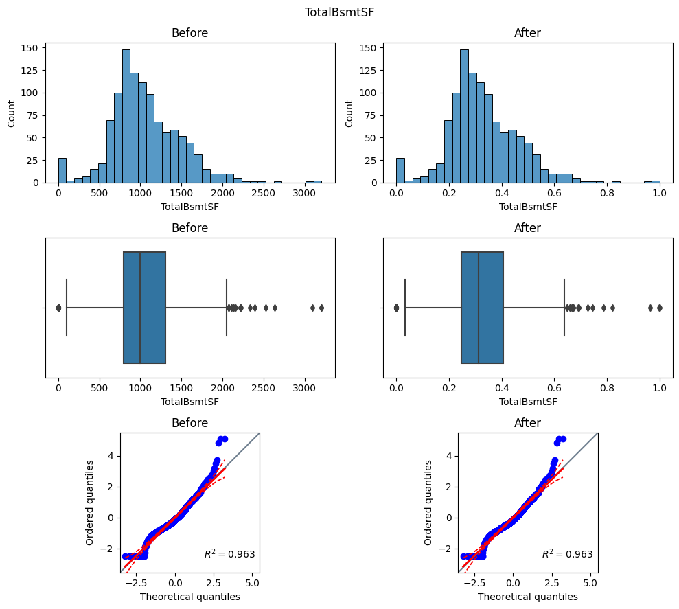

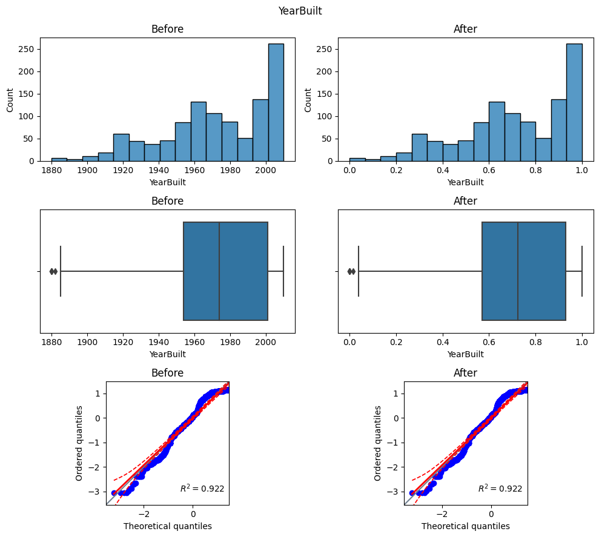

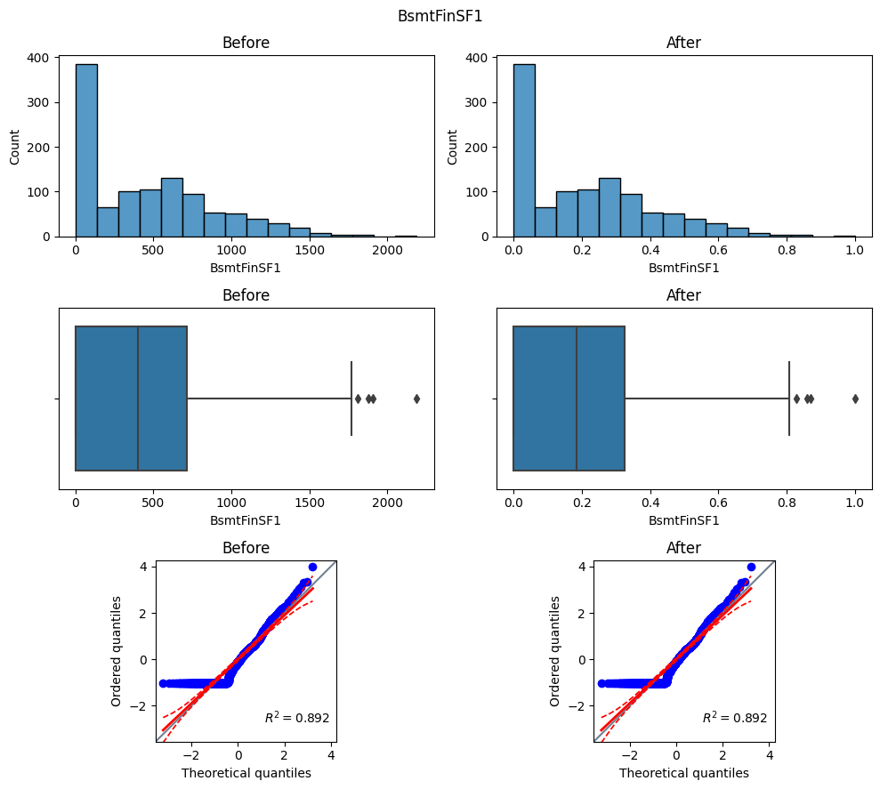

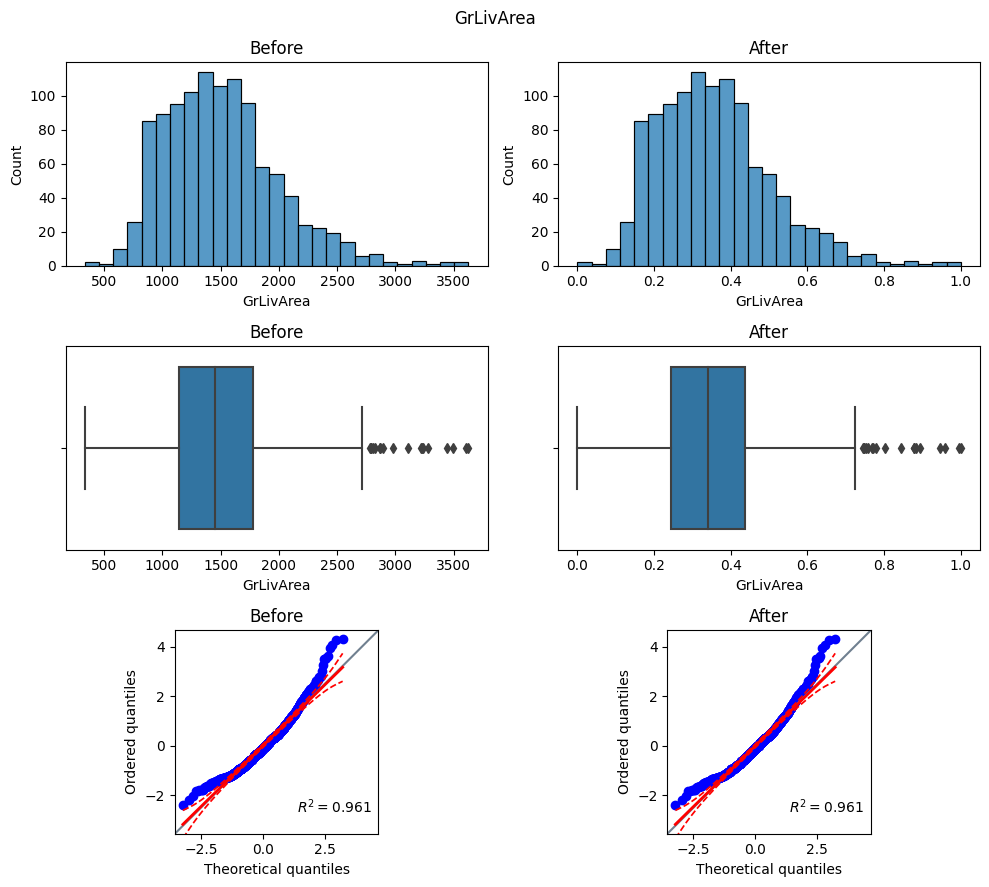

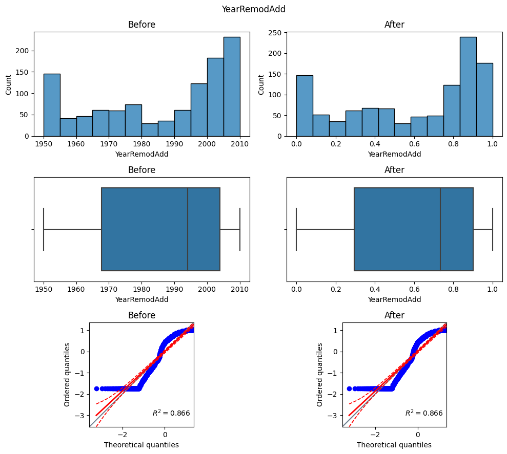

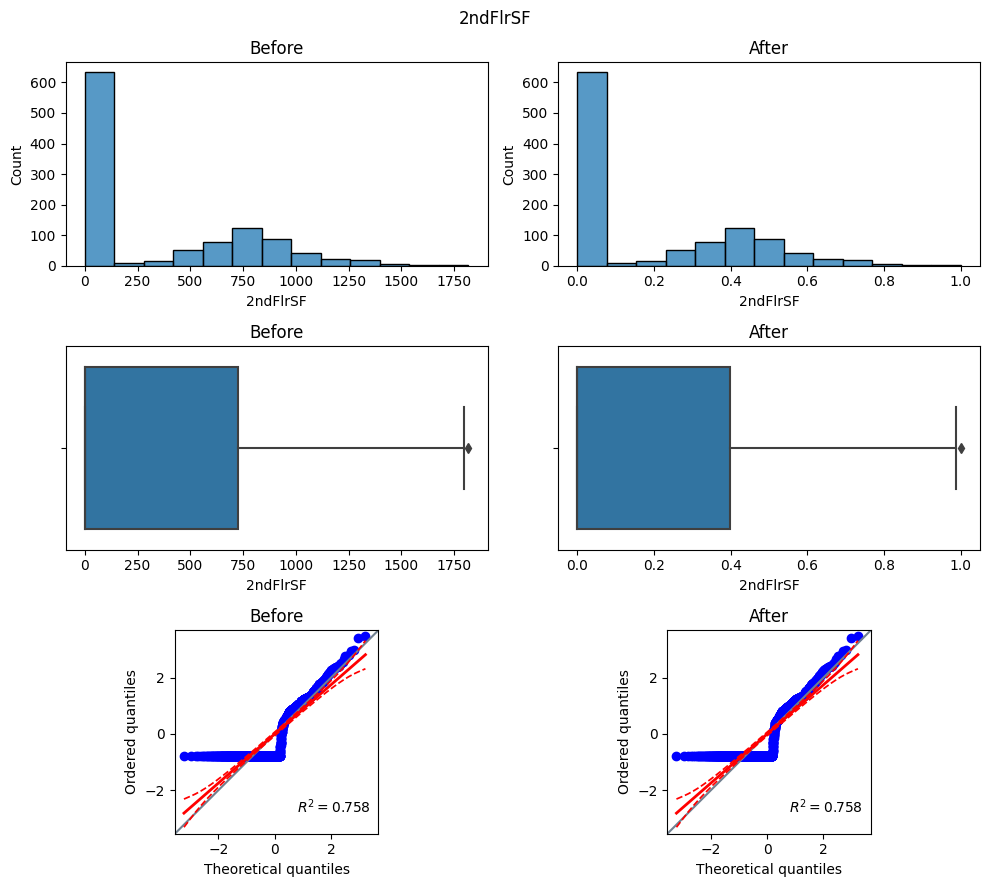

```python
from sklearn.preprocessing import MinMaxScaler

min_max_scaler = MinMaxScaler()
min_max_scaler.set_output(transform='pandas')
evaluate_all_feature_transformations(min_max_scaler)
```

**Variance-stabilizing-transformers**:

Power transformer (exponent=0.5):

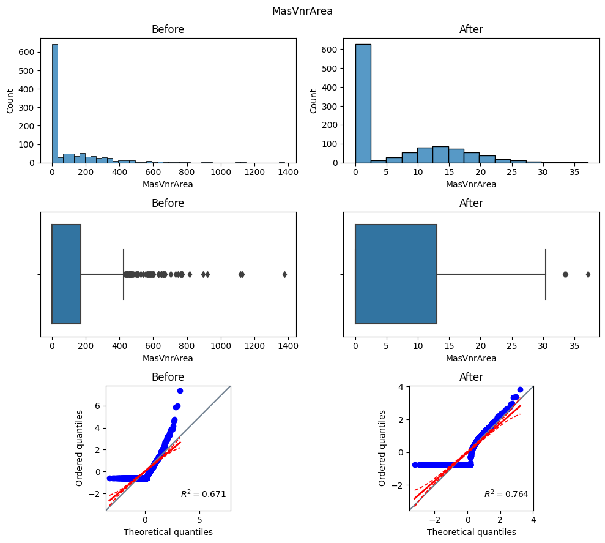

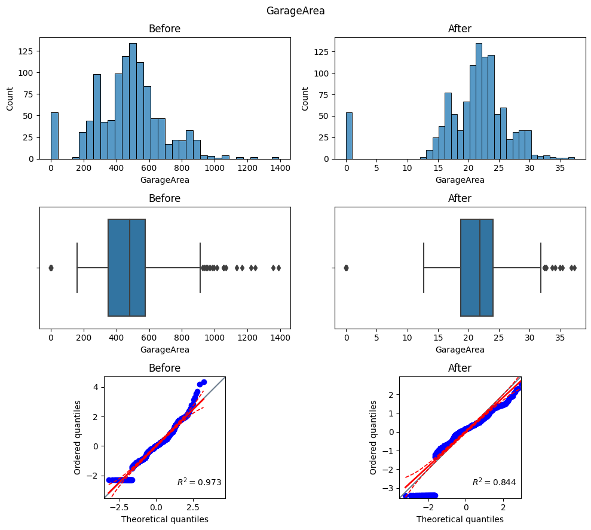

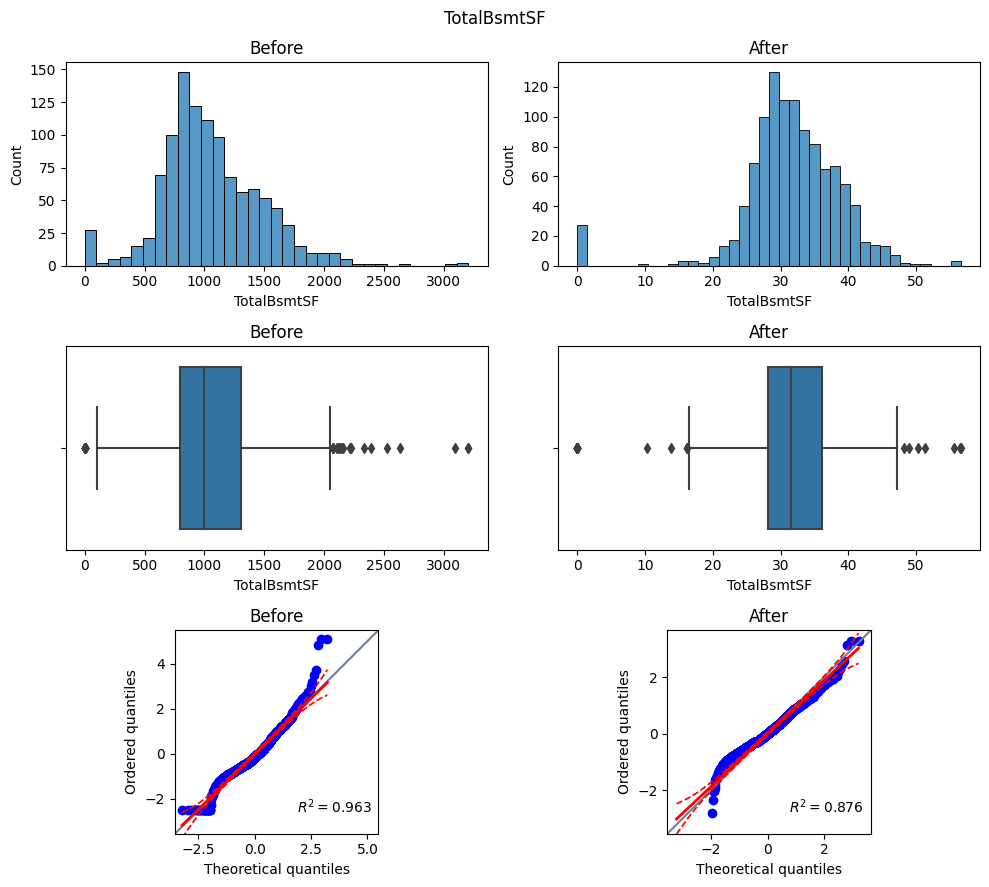

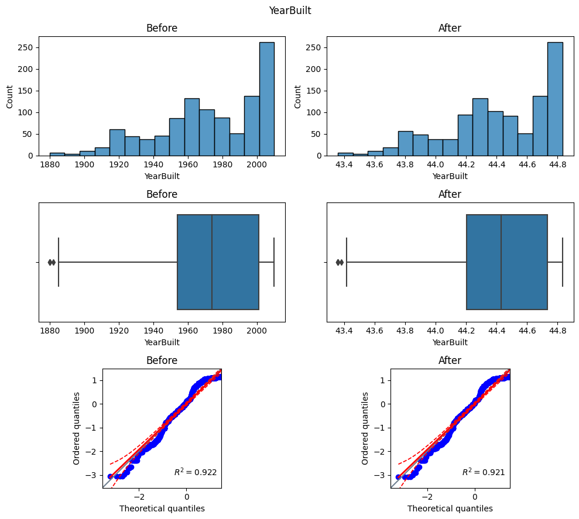

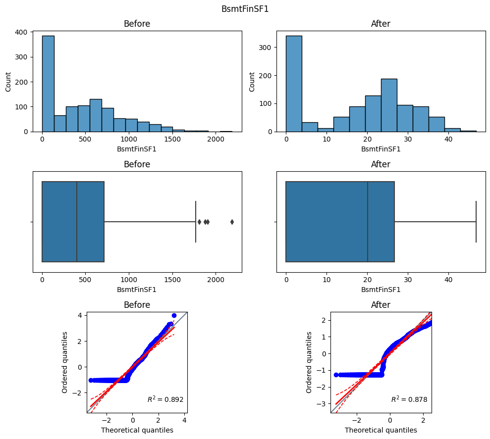

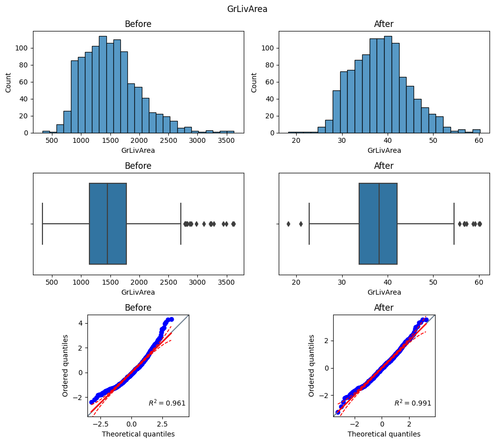

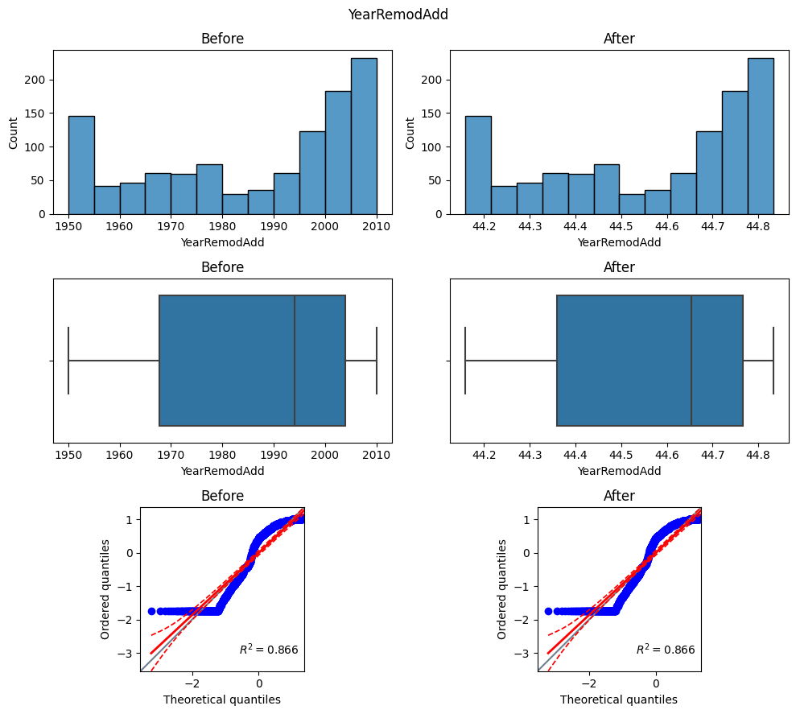

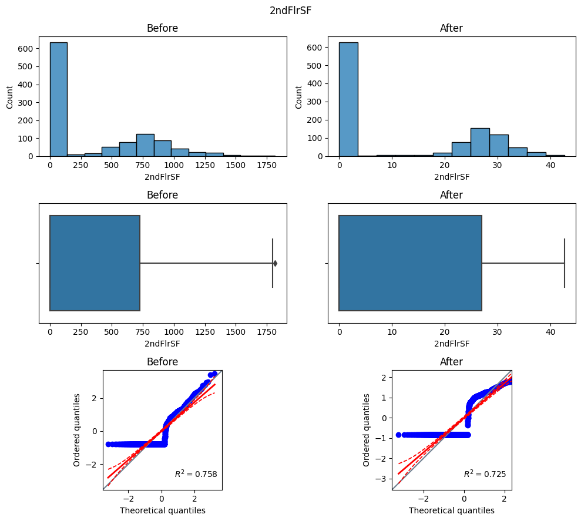

```python
from feature_engine.transformation import PowerTransformer

power_transformer = PowerTransformer()
evaluate_all_feature_transformations(power_transformer)
```

Yeo-Johnson-Transformer:

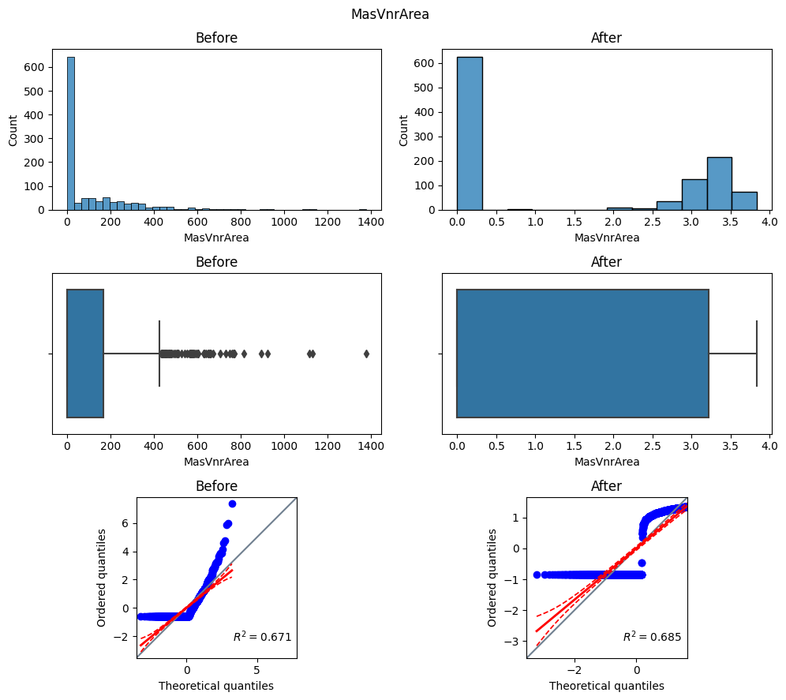

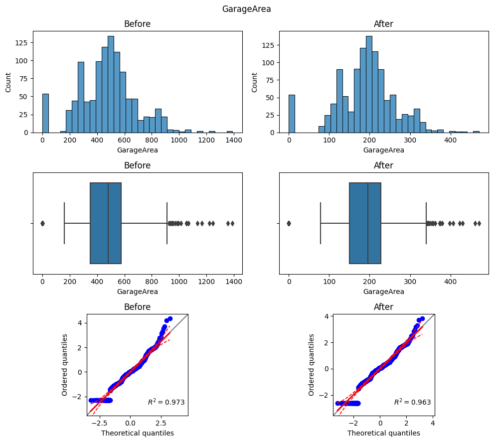

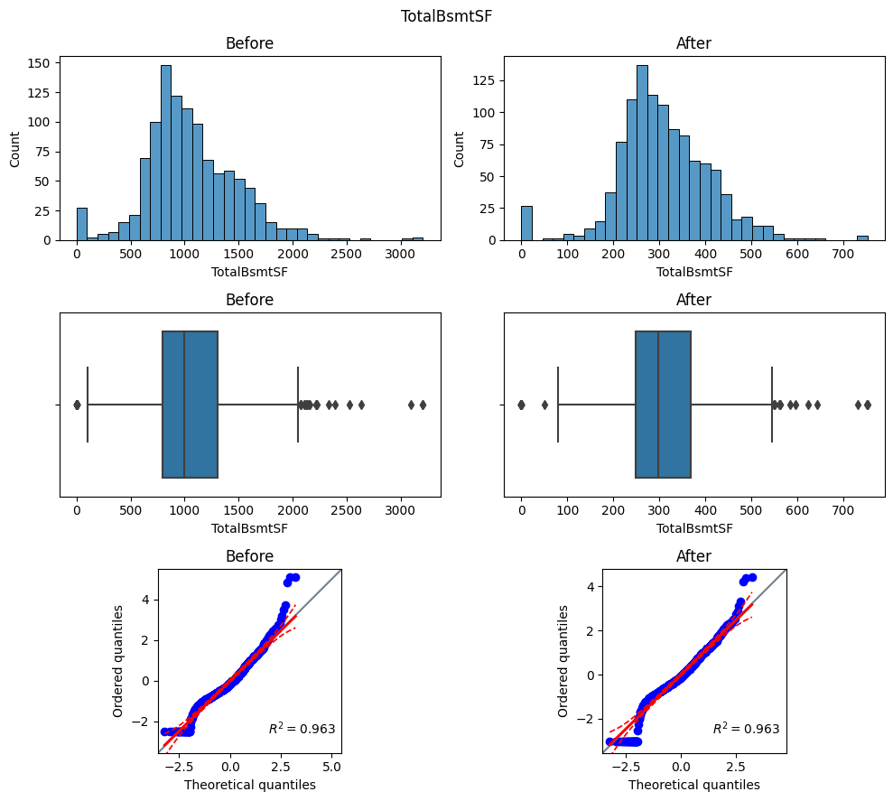

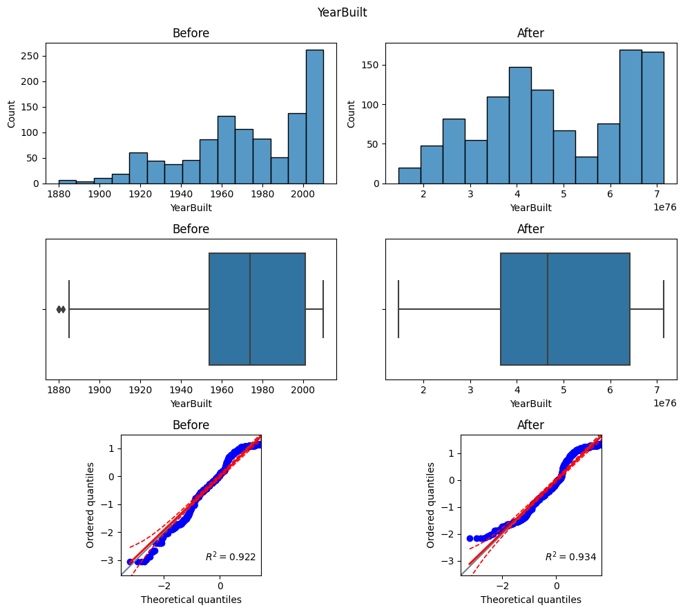

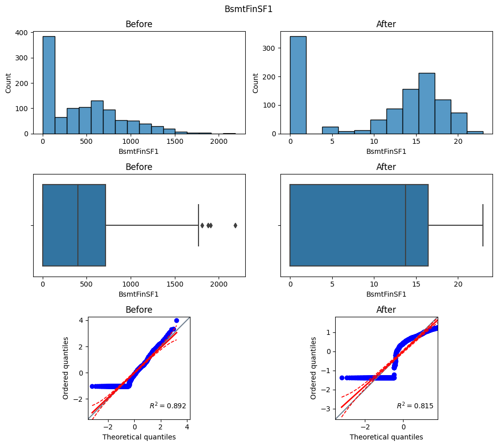

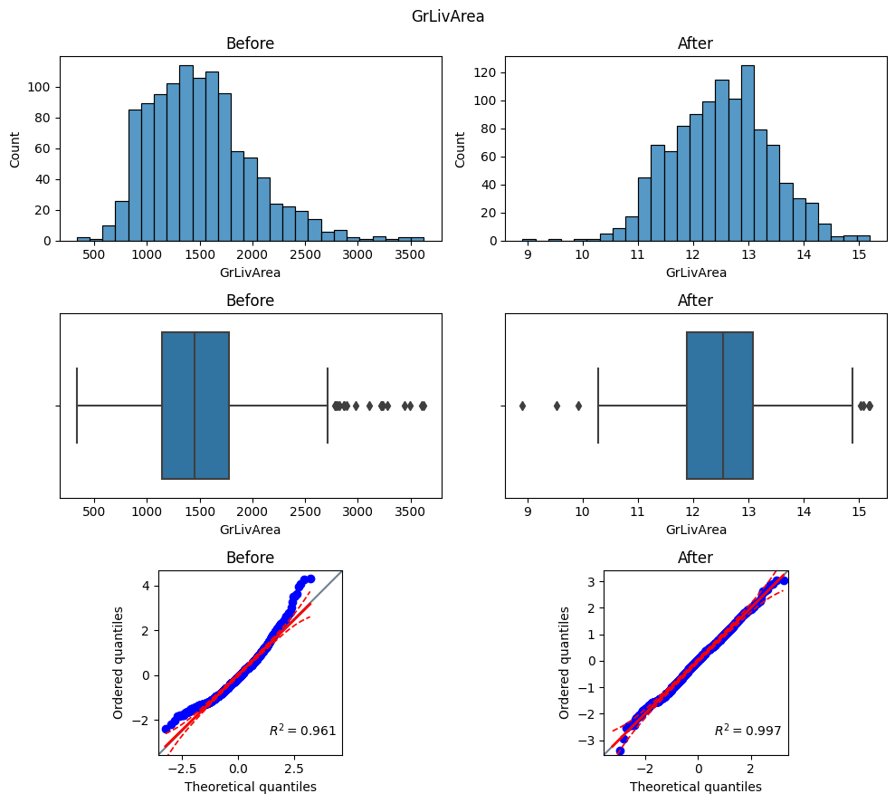

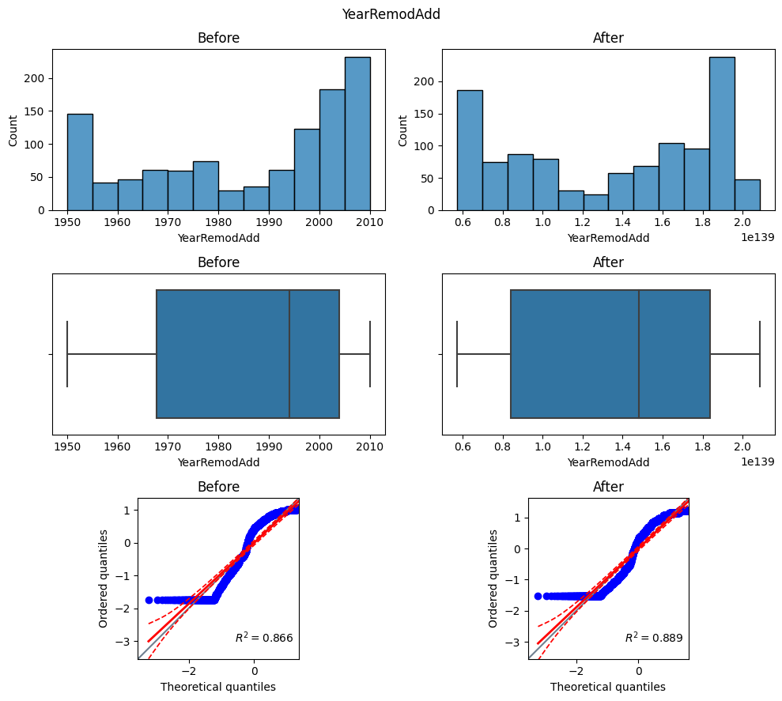

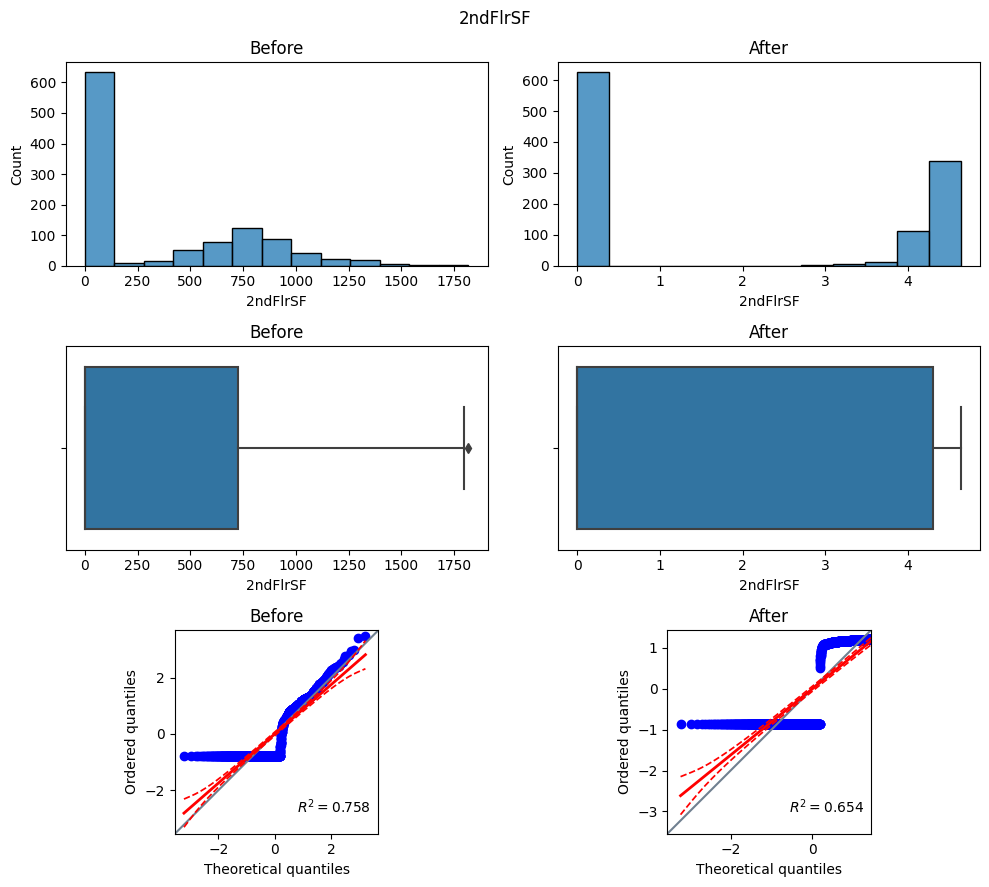

```python
from feature_engine.transformation import YeoJohnsonTransformer

yeo_johnson_transformer = YeoJohnsonTransformer()
evaluate_all_feature_transformations(yeo_johnson_transformer)
```

Further transformations for features with all values > 0

Log transformer (base e):

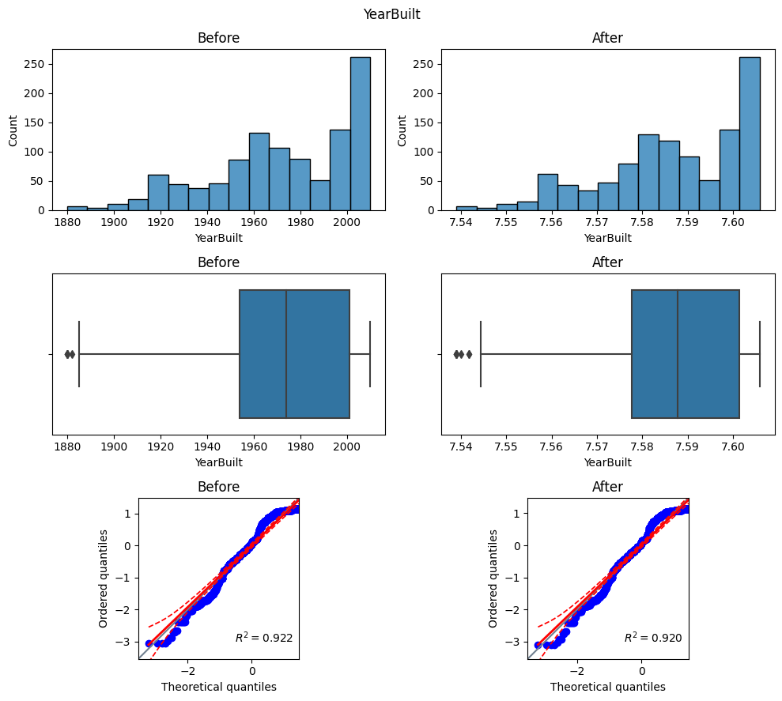

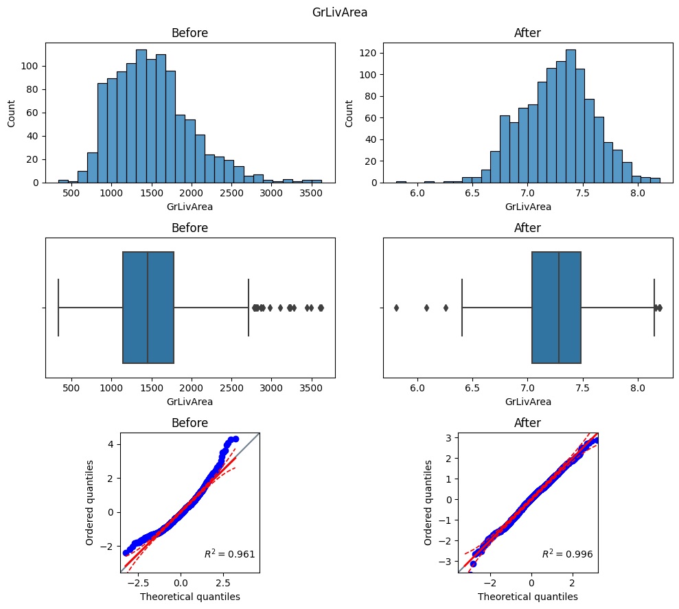

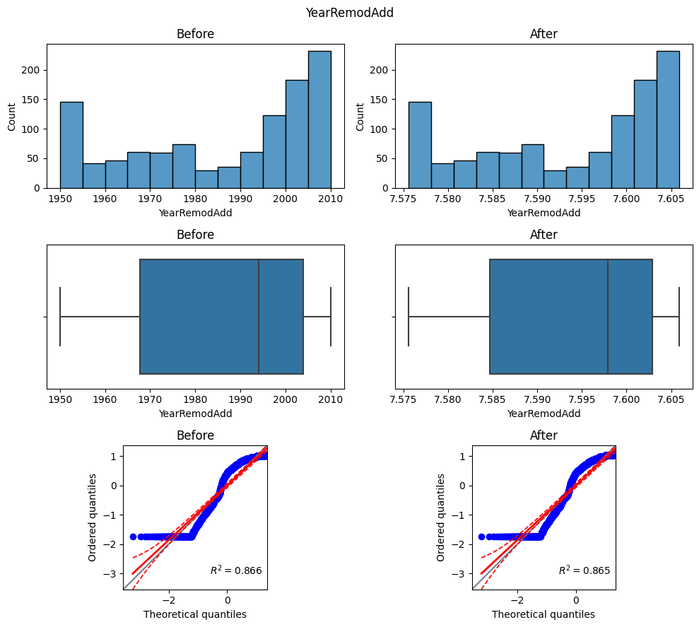

```python
from feature_engine.transformation import LogTransformer

log_transformer = LogTransformer()
evaluate_all_feature_transformations(log_transformer, non_zero=True)
```

Log transformer (base 10):

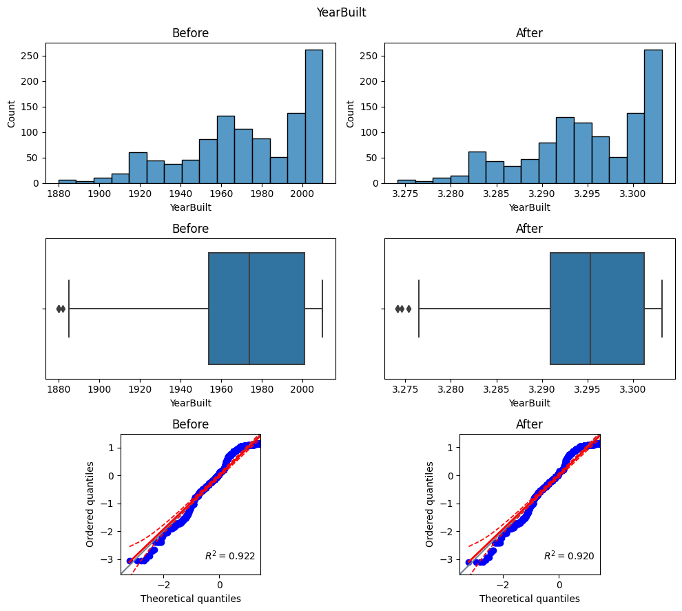

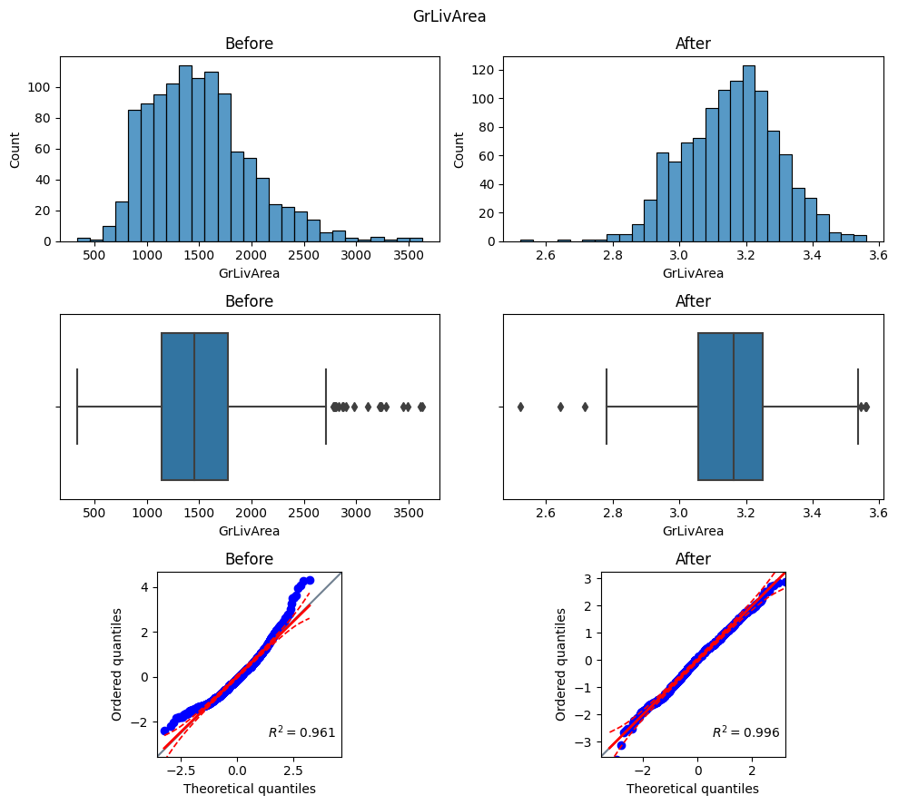

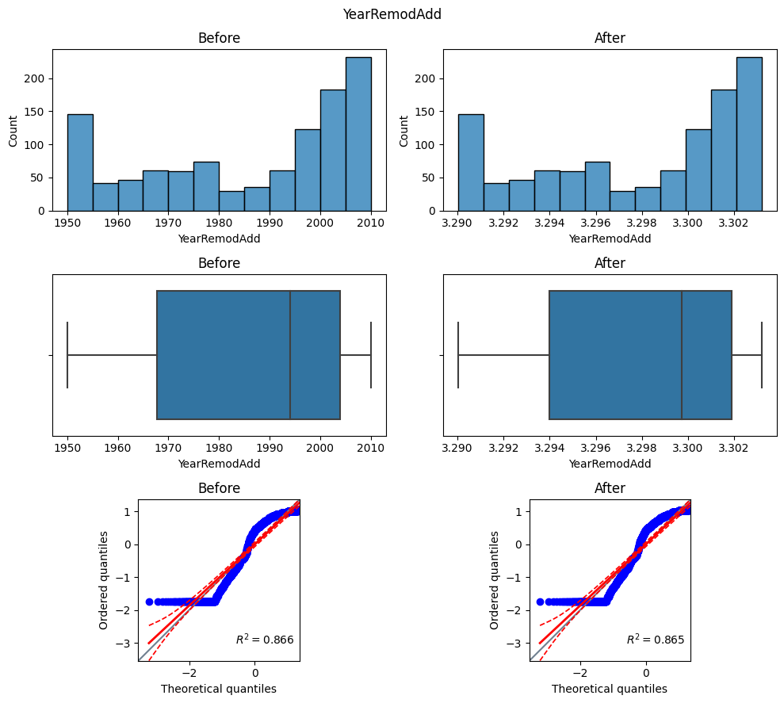

```python
from feature_engine.transformation import LogTransformer

log_transformer = LogTransformer(base='10')
evaluate_all_feature_transformations(log_transformer, non_zero=True)
```

Box-Cox-Transformer:

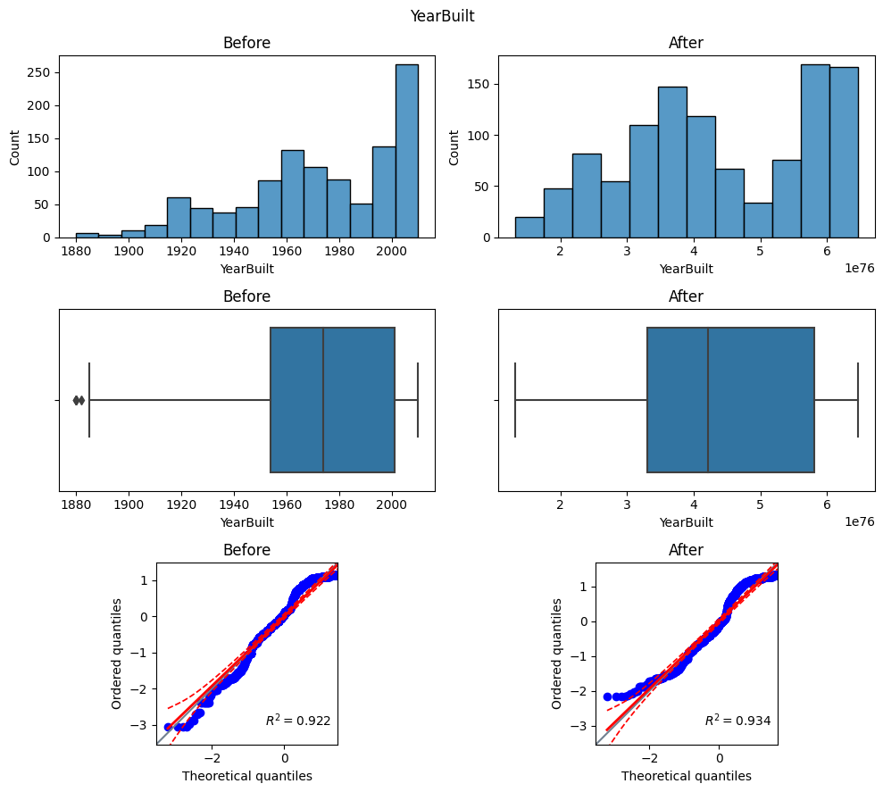

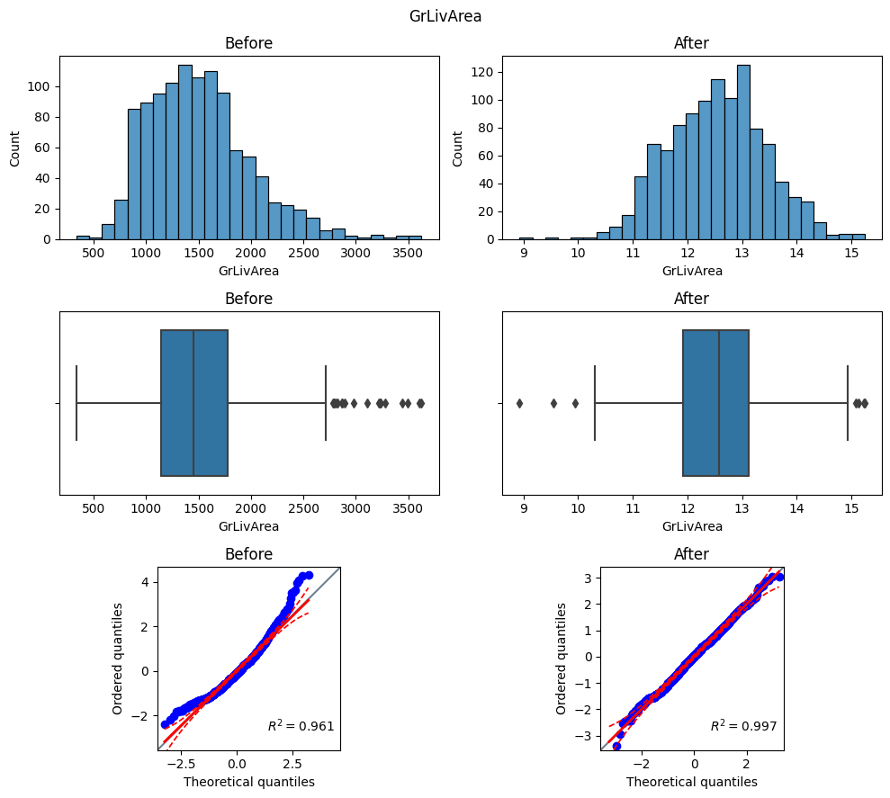

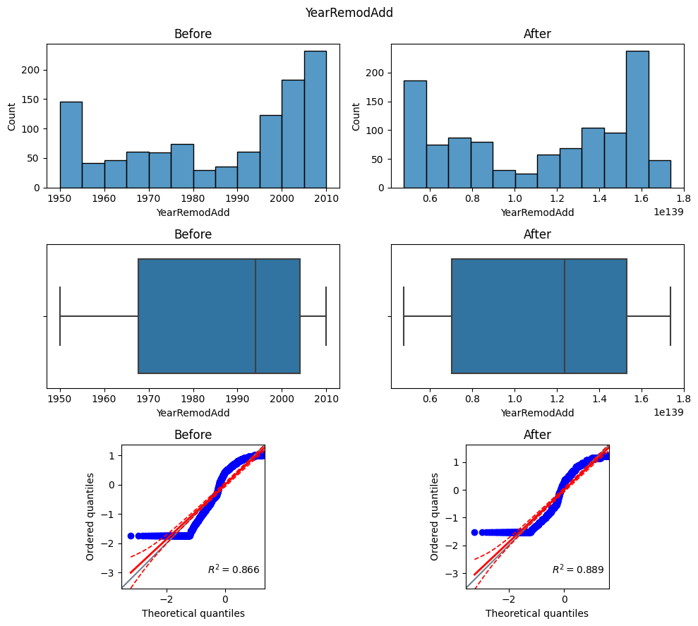

```python
from feature_engine.transformation import BoxCoxTransformer

box_cox_transformer = BoxCoxTransformer()
evaluate_all_feature_transformations(box_cox_transformer, non_zero=True)
```

**Standardise transformers**:

StandardScaler transformer:

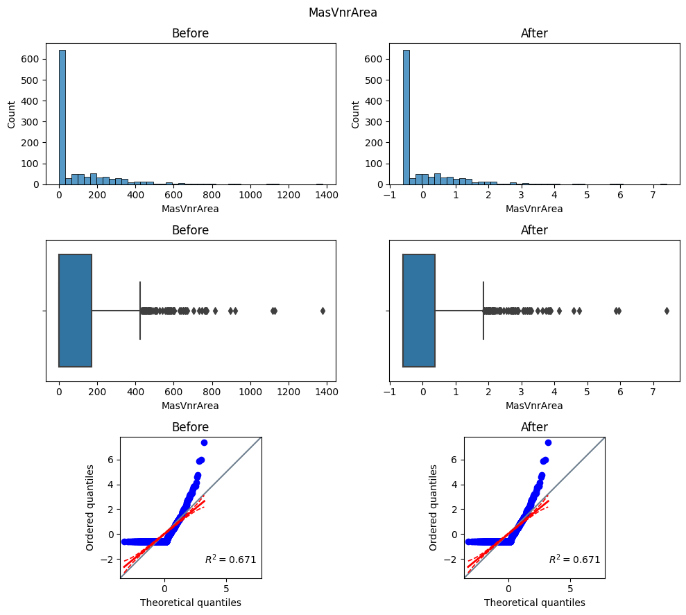

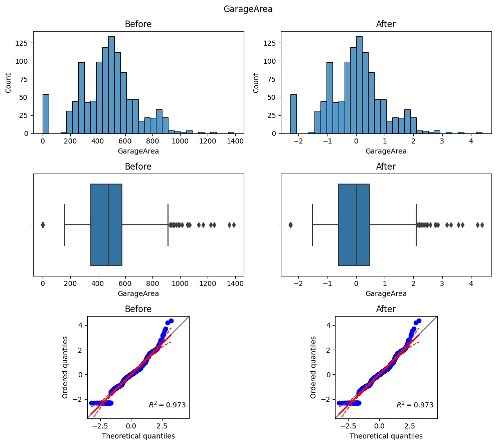

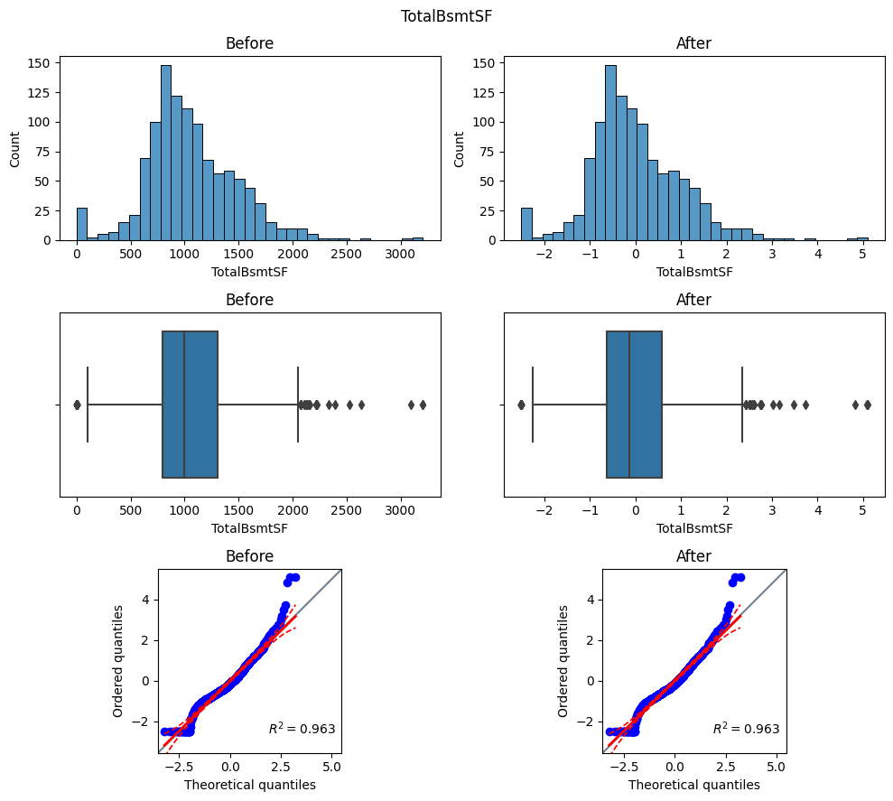

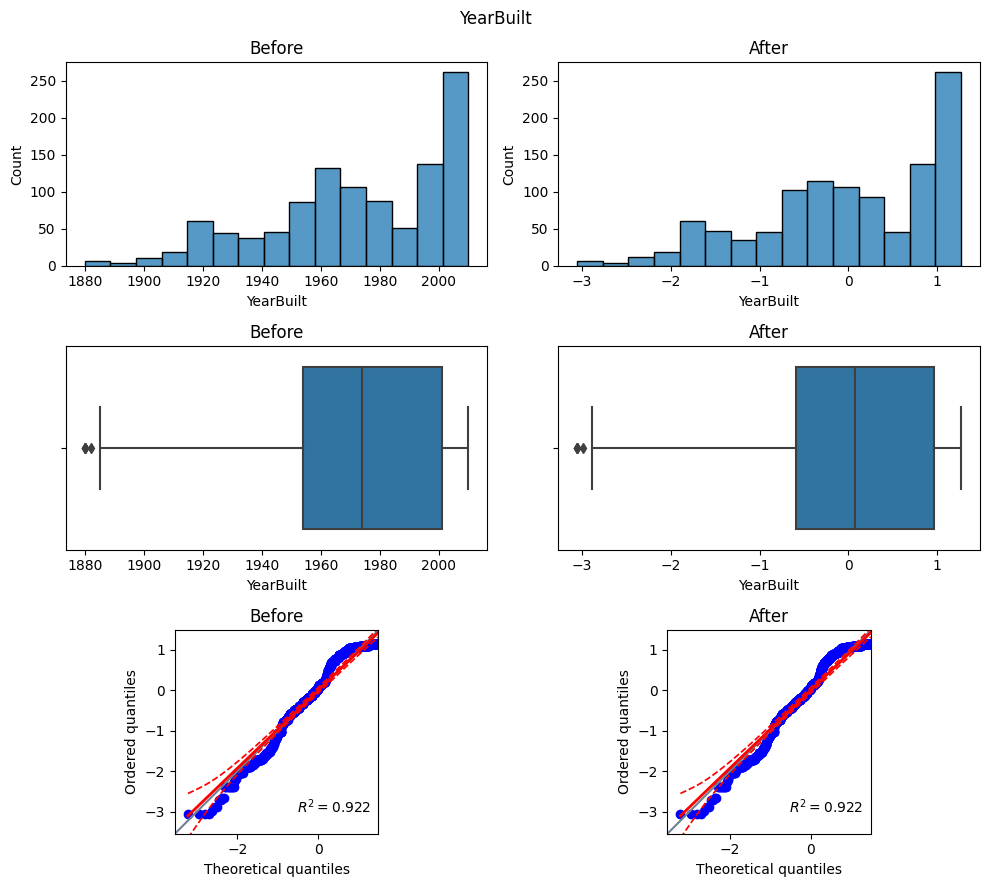

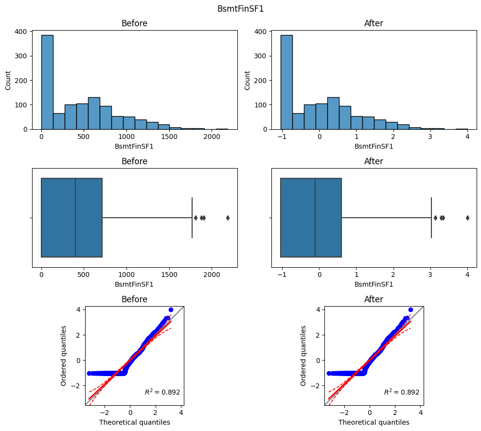

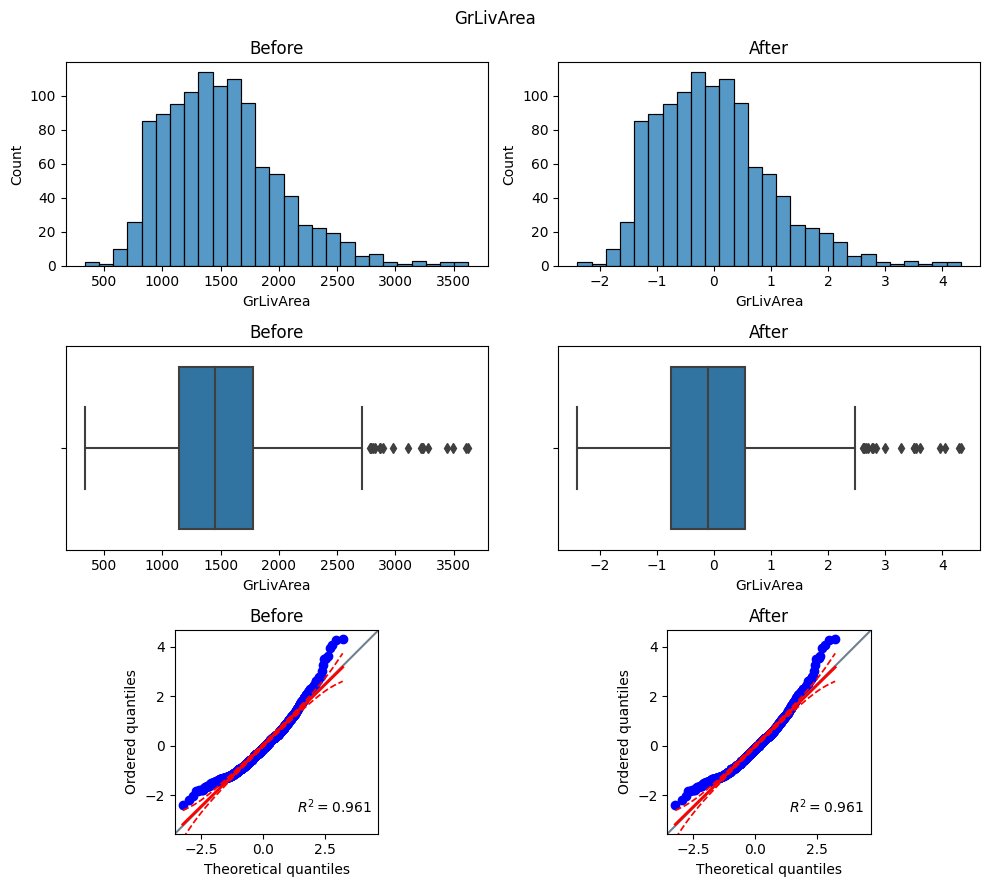

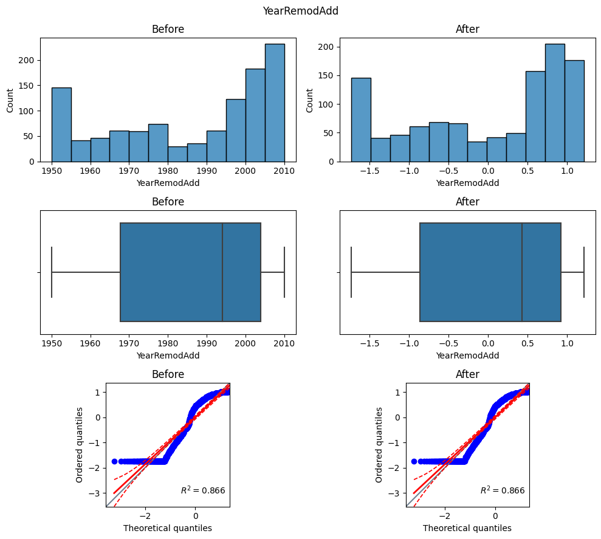

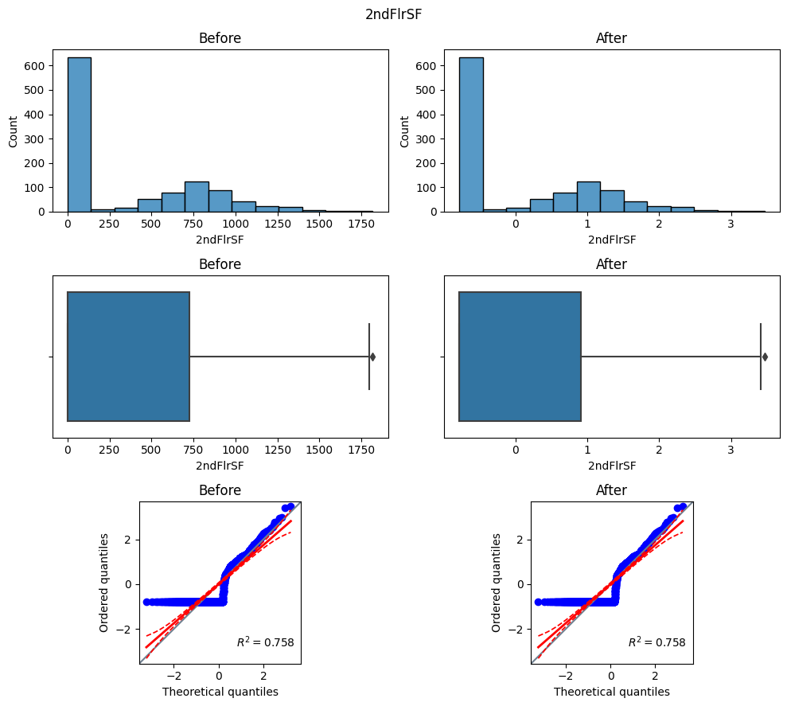

```python
from sklearn.preprocessing import StandardScaler

standard_scaler = StandardScaler()
standard_scaler.set_output(transform='pandas')
evaluate_all_feature_transformations(standard_scaler)
```

### Observations

| Feature | Observations |
| --- | --- |
| YearBuilt | Slight improvement in normality seen with the Yeo-Johnson transformer. |
| TotalBsmtSF | No positive changes in normality. |
| YearRemodAdd | No real improvements in normality achievable. |
| GarageArea | No positive changes in normality seen. |
| GrLivArea | large improvements in normality seen for various transformers |
| 2ndFlrSF | No improvements in normality. |
| BsmtFinSF1 | Improved normality seen with power transformer. |
| MasVnrArea | Perhaps improvement in normality with the power transformer. |

Based on the above observations, the 'YearBuilt', 'GrLivArea' and 'BsmtFinSF1' features will be transformed using the power transformer (power=0.5). All remaining numeric features will be transformed using the sklearn MinMaxScaler transformer.

**Transforming numeric features in train and test sets**

```python
power_transformer = PowerTransformer(variables=['YearBuilt', 'GrLivArea', 'BsmtFinSF1'])
power_transformer.set_output(transform='pandas')

remaining_variables = train_set_numeric_df.drop(axis=1, labels=['YearBuilt', 'GrLivArea', 'BsmtFinSF1']).columns.to_list()
print(remaining_variables)
min_max_scaler = MinMaxScaler()
min_max_scaler.set_output(transform='pandas')

train_set_df[train_set_numeric_df.columns.to_list()] = power_transformer.fit_transform(train_set_numeric_df)
test_set_df[test_set_numeric_df.columns.to_list()] = power_transformer.transform(test_set_numeric_df)

train_set_df[remaining_variables] = min_max_scaler.fit_transform(train_set_df[remaining_variables])
test_set_df[remaining_variables] = min_max_scaler.transform(test_set_numeric_df[remaining_variables])
```

```
['MasVnrArea', 'GarageArea', 'TotalBsmtSF', 'YearRemodAdd', '2ndFlrSF']
```

### Categorical feature scaling

```python
train_set_categorical_df = train_set_df[['KitchenQual', 'OverallQual', 'GarageFinish']]
test_set_categorical_df = test_set_df[['KitchenQual', 'OverallQual', 'GarageFinish']]
```

```python
min_max_scaler = MinMaxScaler()
min_max_scaler.set_output(transform='pandas')
min_max_scaler.fit(train_set_categorical_df)
# transforming train set
train_set_categorical_df = min_max_scaler.transform(train_set_categorical_df)
train_set_df[train_set_categorical_df.columns] = train_set_categorical_df
# transforming test set
test_set_categorical_df = min_max_scaler.transform(test_set_categorical_df)
test_set_df[test_set_categorical_df.columns] = test_set_categorical_df
```

### Target scaling

Some algorithms require the target to be normalised for optimal performance, consequently the target will be normalised (range 0-1) using the MinMaxScaler.

train set target:

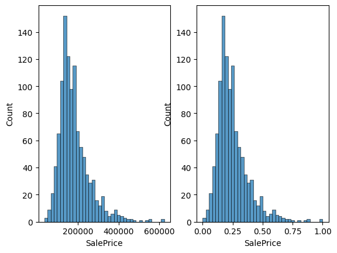

```python
fig , axes = plt.subplots(ncols=2)
# before scaling histogram
sns.histplot(data=train_set_df['SalePrice'], ax=axes[0])

min_max_scaler = MinMaxScaler()
min_max_scaler.set_output(transform='pandas')
min_max_scaler.fit(train_set_df[['SalePrice']])
transformed_df = min_max_scaler.transform(train_set_df[['SalePrice']])
train_set_df[['SalePrice']] = transformed_df
# histogram after scaling
sns.histplot(data=train_set_df['SalePrice'], ax=axes[1])
```

test set target:

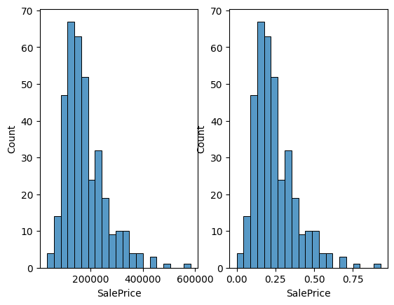

```python
fig , axes = plt.subplots(ncols=2)
# before scaling histogram
sns.histplot(data=test_set_df['SalePrice'], ax=axes[0])

transformed_df = min_max_scaler.transform(test_set_df[['SalePrice']])
test_set_df[['SalePrice']] = transformed_df
# histogram after scaling
sns.histplot(data=test_set_df['SalePrice'], ax=axes[1])
```

```python
print(train_set_df.head())
test_set_df.head()
```

```
   MasVnrArea  GarageArea  TotalBsmtSF  YearBuilt  BsmtFinSF1  GrLivArea  \
0    0.000000    0.129496     0.320649  44.102154   27.820855  48.166378
1    0.000000    0.478417     0.488147  44.452222   34.132096  53.833075
2    0.105225    0.409353     0.473487  44.598206   38.961519  40.546270
3    0.000000    0.482014     0.447286  44.754888   36.755952  46.357308
4    0.000000    0.414388     0.347473  44.754888   28.530685  33.376639

   OverallQual  GarageFinish  YearRemodAdd  KitchenQual  2ndFlrSF  SalePrice
0     0.555556      0.333333      0.866667     0.666667  0.486249   0.380613
1     0.777778      1.000000      0.433333     0.666667  0.000000   0.427216
2     0.666667      1.000000      0.650000     0.666667  0.000000   0.406880
3     0.666667      0.666667      0.883333     0.666667  0.347085   0.347036
4     0.555556      0.333333      0.900000     0.666667  0.000000   0.203525
```

|  | MasVnrArea | GarageArea | TotalBsmtSF | YearBuilt | BsmtFinSF1 | GrLivArea | OverallQual | GarageFinish | YearRemodAdd | KitchenQual | 2ndFlrSF | SalePrice |
| --- | --- | --- | --- | --- | --- | --- | --- | --- | --- | --- | --- | --- |
| 0 | 0.000000 | 0.172662 | 0.235808 | 44.045431 | 17.663522 | 33.674916 | 0.444444 | 0.333333 | 0.000000 | 0.333333 | 0.207921 | 0.154381 |
| 1 | 0.384615 | 0.425899 | 0.338740 | 44.698993 | 30.919250 | 43.863424 | 0.777778 | 0.666667 | 0.800000 | 0.666667 | 0.460946 | 0.415353 |
| 2 | 0.254717 | 0.531655 | 0.512477 | 44.395946 | 34.914181 | 42.708313 | 0.666667 | 0.333333 | 0.866667 | 0.666667 | 0.000000 | 0.452635 |
| 3 | 0.668360 | 0.639568 | 0.394261 | 44.676616 | 0.000000 | 48.414874 | 0.666667 | 0.666667 | 0.783333 | 0.666667 | 0.586909 | 0.389934 |
| 4 | 0.000000 | 0.750360 | 0.337492 | 44.777226 | 0.000000 | 44.192760 | 0.777778 | 0.666667 | 0.933333 | 0.666667 | 0.479098 | 0.367904 |

## Creating custom transformers for pipelines

Creating the initial feature selection custom transformer:

```python
from sklearn.base import BaseEstimator, TransformerMixin
class CompositeSelectKBest(BaseEstimator, TransformerMixin):
    """
    Custom transformer that is a composition of two SelectKBest transformers.

    Filters out a set union of best features, from a dataset with a SalePrice target.
    """
    def spearman_score_function(self, feature_array, target_array):
        """
        Calculates spearman correlation coefficients for x's features and y's target.

        To be used as the score function in the sklearn.feature_selection.SelectKBest function.

        Args:
            feature_array = array-like, containing x data.
            target_array = array-like, containing y data.

        Returns tuple of the spearman r values series, and the spearman p values series for the dataset.
        """
        df = pd.DataFrame(data=feature_array, columns=self.x_column_names)
        df['SalePrice'] = target_array
        spearman_df = df.pairwise_corr(columns=['SalePrice'], method='spearman')
        return (spearman_df['r'], spearman_df['p-unc'])


    def phik_score_function(self, feature_array, target_array):
        """
        Calculates phi_k correlation coefficients for x's features and y's target.

        To be used as the score function in the sklearn.feature_selection.SelectKBest function.

        Args:
            feature_array = array-like, containing x data.
            target_array = array-like, containing y data

        Returns tuple of the phi_k correlation values series, and the significance values series for the dataset.
        """
        df = pd.DataFrame(data=feature_array, columns=self.x_column_names)
        df['SalePrice'] = target_array

        phik_matrix_df = phik_matrix(df)[['SalePrice']].drop('SalePrice', axis=0)
        significance_matrix_df = significance_matrix(df)[['SalePrice']].drop('SalePrice', axis=0)
        return (phik_matrix_df['SalePrice'], significance_matrix_df['SalePrice'])


    def fit(self, x, y):
        """
        Composed of two SelectKBest fittings with spearman and phi_k score functions
        """
        self.x_column_names = x.columns.to_list()
        select_k_best_spear = SelectKBest(score_func=self.spearman_score_function)
        select_k_best_spear.set_output(transform='pandas')
        self.spear_trans = select_k_best_spear.fit(x, y)

        select_k_best_phi = SelectKBest(score_func=self.phik_score_function)
        select_k_best_phi.set_output(transform='pandas')
        self.phik_trans = select_k_best_phi.fit(x, y)

        return self

    def transform(self, x):
        """
        Filters out the union of each set of the 10 best features obtained using the SelectKBest method with a phi_k and spearman score function.
        """
        spearman_transformed_df = self.spear_trans.transform(x)
        phik_transformed_df = self.phik_trans.transform(x)

        selected_features = list(set(spearman_transformed_df.columns.to_list() + phik_transformed_df.columns.to_list()))
        x = x[selected_features]
        return x

    def set_output(self, transform):
        pass
```

## Conclusions

**Data cleaning and feature engineering pipeline steps**

- Will use an OrdinalEncoder transformer to encode the categorical variables: ['BsmtExposure', 'BsmtFinType1', 'GarageFinish', 'KitchenQual'], using the orderings:

bsmt_fin_type1_cat = np.array(['None', 'Unf', 'LwQ', 'Rec', 'BLQ', 'ALQ', 'GLQ'])  
bsmt_exposure_cat = np.array(['None', 'No', 'Mn', 'Av', 'Gd'])  
garage_finish_cat = np.array(['None', 'Unf', 'RFn', 'Fin'])  
kitchen_quality_cat = np.array(['Po', 'Fa', 'TA', 'Gd', 'Ex'])

- For an initial feature selection will use a custom transformer CompositeSelectKBest with all features.
- Will then remove redundant features using a SmartCorrelatedSelection transformer with decision tree estimator.
- Will transform the features: ['YearBuilt', 'GrLivArea', 'BsmtFinSF1'], using a power transformer.
- Will then scale all remaining features using a MinMaxScaler transformer.
- Will also scale the target using a MinMaxScaler.